Statistical Learning · R · tidymodels

# Cross-Validation for Model Selection

Evaluating polynomial regression models for fuel efficiency prediction using validation set and k-fold cross-validation methods on the Auto dataset.

Author Saroj Bhatta

Dataset ISLR Auto

Methods CV · Polynomial Regression

## Background & Theory

Cross-validation is a resampling technique used to estimate how well a statistical model will generalize to an independent dataset. Rather than evaluating a model on the same data used to train it—which can lead to overly optimistic performance estimates—cross-validation holds out portions of the data to simulate performance on unseen observations.

### K-Fold Cross-Validation

In k-fold CV, the dataset is randomly partitioned into *K* equal-sized folds. The model is trained on K−1 folds and evaluated on the held-out fold, rotating through all K folds. The final performance estimate is the average across all K iterations, producing a lower-variance estimate than a single train/test split.

**Comparison with alternatives:** The validation set approach is simple but produces high-variance estimates depending on the random split. Leave-one-out CV (LOOCV) is nearly unbiased but computationally expensive and can yield high variance. K-fold CV strikes a practical balance between bias, variance, and computational cost.

## Dataset Overview

The analysis uses the **Auto** dataset from the ISLR package, which contains fuel efficiency and technical specifications for 392 automobiles. The outcome of interest is `mpg` (miles per gallon), and the primary predictor is `horsepower`.

```
library(tidyverse)
library(tidymodels)
library(ISLR)

glimpse(Auto)
```

Rows: 392 | Columns: 9 Variables: mpg, cylinders, displacement, horsepower, weight, acceleration, year, origin, name sum(is.na(Auto)) [1] 0

The dataset contains 392 complete observations across 9 variables, with no missing values confirmed both via `sum(is.na())` and by verifying that `drop_na()` does not reduce the row count.

## Exploratory Analysis

### Distribution of MPG

The distribution of MPG is right-skewed, with most vehicles clustered between 15–30 MPG and a smaller number of more fuel-efficient vehicles extending the tail toward higher values.

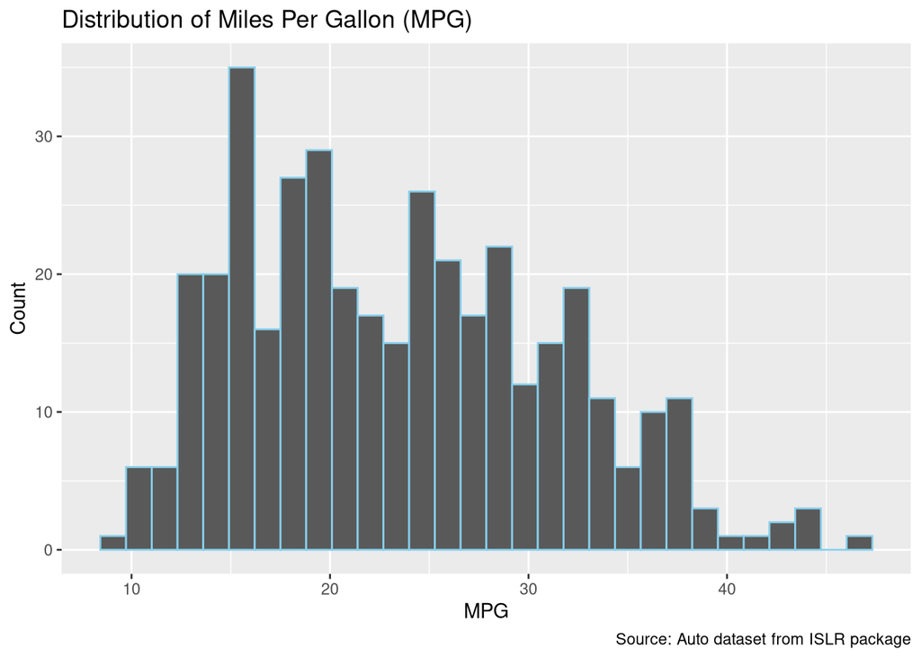

Figure 1. Distribution of miles per gallon (MPG) across 392 vehicles.

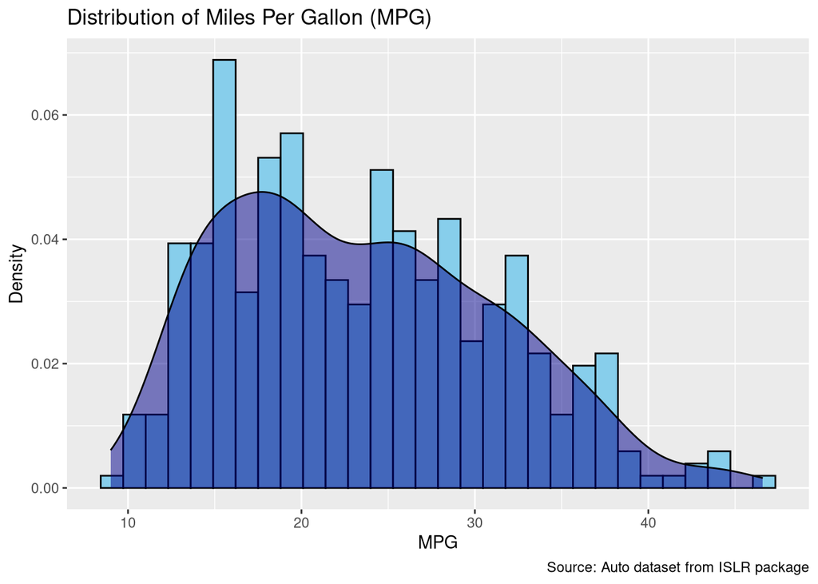

Figure 2. MPG distribution with overlaid kernel density estimate.

### MPG vs. Horsepower

The scatterplot reveals a clear negative, non-linear relationship between horsepower and MPG: higher-horsepower vehicles tend to achieve lower fuel efficiency, with the relationship showing diminishing curvature at higher horsepower values—suggesting that a polynomial model may better capture this trend than a simple linear fit.

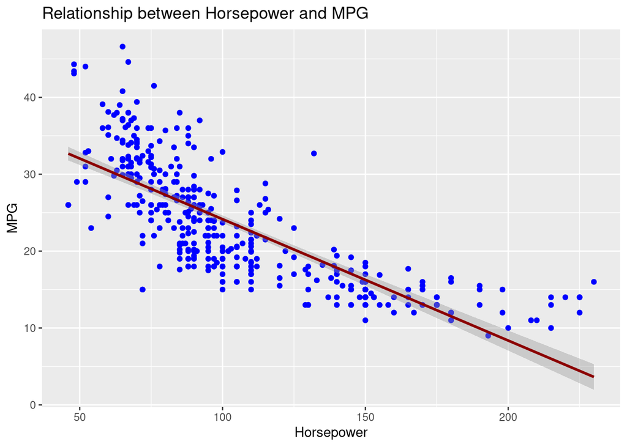

Figure 3. Relationship between horsepower and MPG with a linear regression smoother.

## Validation Set Approach

The data was split into training (75%, n=294) and testing (25%, n=98) sets using a fixed seed for reproducibility. Three polynomial regression models of increasing flexibility were fit on the training data and evaluated on the held-out test set.

```
set.seed(42)
auto_split <- initial_split(data = Auto, prop = 3/4)
Auto_train <- training(auto_split)
Auto_test  <- testing(auto_split)

lm_spec <- linear_reg() |> set_engine("lm")

# Model 1: Linear
lm1_results <- last_fit(lm_spec, mpg ~ horsepower, split = auto_split)

# Model 2: Quadratic
lm2_results <- last_fit(lm_spec, mpg ~ horsepower + I(horsepower^2), split = auto_split)

# Model 3: Cubic
lm3_results <- last_fit(lm_spec, mpg ~ horsepower + I(horsepower^2) + I(horsepower^3), split = auto_split)
```

| Model | Formula | Test RMSE | Test R² |
| --- | --- | --- | --- |
| Model 1 | mpg ~ horsepower | 5.11 | 0.617 |
| Model 2 | mpg ~ horsepower + hp² | 4.56 | 0.700 |
| Model 3 | mpg ~ horsepower + hp² + hp³ | 4.56 | 0.701 |

Model 2 and Model 3 achieve essentially the same test RMSE (4.56), while Model 1 performs notably worse (5.11). Adding the cubic term provides negligible improvement over the quadratic model. Applying the principle of parsimony, **Model 2 (quadratic)** is preferred—it captures the non-linear relationship without unnecessary complexity that could overfit.

## 5-Fold Cross-Validation

To obtain more reliable performance estimates, the same three models were re-evaluated using 5-fold cross-validation on the full dataset. This ensures that every observation participates in both training and evaluation across the five folds.

```
set.seed(143)
auto_cv <- vfold_cv(Auto, 5)

results1 <- fit_resamples(lm_spec, mpg ~ horsepower, resamples = auto_cv)
results2 <- fit_resamples(lm_spec, mpg ~ poly(horsepower, 2), resamples = auto_cv)
results3 <- fit_resamples(lm_spec, mpg ~ poly(horsepower, 3), resamples = auto_cv)
```

| Model | Mean CV RMSE | Mean CV R² |
| --- | --- | --- |
| Model 1 (Linear) | 4.95 | 0.618 |
| Model 2 (Quadratic) | 4.38 | 0.687 |
| Model 3 (Cubic) | 4.39 | 0.686 |

The 5-fold CV results confirm the validation set findings: Model 2 achieves the lowest mean CV RMSE (4.38), with Model 3 (4.39) providing no meaningful improvement. The quadratic polynomial is again the preferred model.

## Automated Tuning with tune_grid()

Rather than manually fitting models at fixed polynomial degrees, `step_poly(horsepower, degree = tune())` was used within a tidymodels recipe to automate the search over polynomial degrees. This step creates orthogonal polynomial basis expansions of the predictor, with the degree treated as a hyperparameter to be optimized via cross-validation.

```
auto_prep <- Auto |>
  recipe(mpg ~ horsepower) |>
  step_poly(horsepower, degree = tune())

auto_tune <- tune_grid(lm_spec, auto_prep, resamples = auto_cv)
```

# A tibble: 6 × 7 degree .metric .estimator mean n std_err .config <int> <chr> <chr> <dbl> <int> <dbl> <chr> 1 2 rmse standard 4.38 5 0.115 Preprocessor1_Model1 2 1 rmse standard 4.95 5 0.131 Preprocessor2_Model1 3 3 rmse standard 4.39 5 0.119 Preprocessor3_Model1

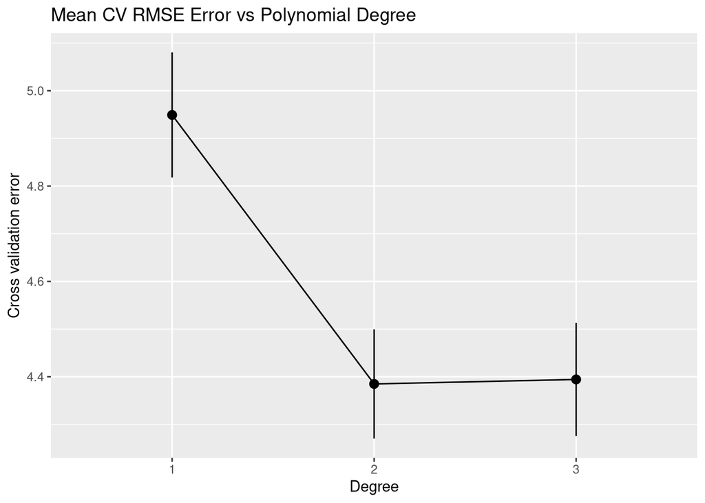

Figure 4. Mean 5-fold cross-validation RMSE across polynomial degrees with ±1 standard error bars.

### Summary & Conclusions

Across both the validation set approach and 5-fold cross-validation, a **quadratic (degree-2) polynomial** of horsepower provides the best model for predicting MPG. It reduces test RMSE from 5.11 (linear) to 4.56 and CV RMSE from 4.95 to 4.38—a meaningful improvement reflecting the non-linear nature of the relationship.

The cubic model adds no practical value: its RMSE is nearly identical to the quadratic and its additional parameter introduces unnecessary complexity. This analysis illustrates the core benefit of cross-validation—it guards against both underfitting and overfitting by providing reliable out-of-sample performance estimates without relying on a single arbitrary data split.